# Assignment_3_MIS_64060-001

# b. Interpret the clusters with respect to the numerical variables used in forming the clusters.

Finding out how the variables profile in each cluster by looking at the means of these numeric variables in 5 different clusters.

```r
kmeans_clustering_w_5_clusters %>%
  augment(pharm_data_numeric) %>%
  dplyr::select(-.rownames) %>%
  group_by(.cluster) %>%
  summarise_all(mean)
```

```
## # A tibble: 5 × 10
##   .cluster Marke…¹   Beta PE_Ra…²    ROE    ROA Asset…³ Lever…⁴ Rev_G…⁵ Net_Pr…⁶
##   <fct>      <dbl>  <dbl>   <dbl>  <dbl>  <dbl>   <dbl>   <dbl>   <dbl>    <dbl>
## 1 1        -0.0314 -0.436 -0.317   0.195  0.408   0.173 -0.274   -0.704  0.557
## 2 2        -0.871   1.34  -0.0528 -0.618 -1.19   -0.461  1.37    -0.691 -1.32
## 3 3        -0.439  -0.470  2.70   -0.835 -0.923   0.231 -0.142   -0.117 -1.42
## 4 4         1.70   -0.178 -0.198   1.23   1.35    1.15  -0.468    0.467  0.591
## 5 5        -0.760   0.280 -0.477  -0.744 -0.811  -1.27   0.0631   1.52  -0.00689
## # … with abbreviated variable names ¹Market_Cap, ²PE_Ratio, ³Asset_Turnover,
## #   ⁴Leverage, ⁵Rev_Growth, ⁶Net_Profit_Margin
```

Cluster 1 seems to represent companies with above-average returns on equity and assets, as well as above-average net profit margins. They have slightly above-average asset turnover, indicating they are utilizing their assets efficiently. They have below-average beta, PE ratio, and leverage, suggesting that they may be less risky and have lower debt levels compared to the overall population.

Cluster 2 seems to represent companies with small market capitalizations and high levels of leverage, suggesting that they may be more risky and have higher debt levels compared to the overall population. They have below-average returns on equity and assets, as well as below-average net profit margins. Their beta is well above the overall mean, indicating they are highly correlated with the market.

Cluster 3 seems to represent companies with high PE ratios, which may indicate that they are relatively expensive compared to the overall population. They have below-average returns on equity and assets, as well as below-average net profit margins. They have slightly above-average asset turnover and slightly below-average leverage, indicating they are utilizing their assets efficiently and have lower debt levels compared to the overall population.

Cluster 4 seems to represent companies with high market capitalizations, above-average returns on equity and assets, as well as above-average net profit margins. They have well above-average asset turnover, indicating they are utilizing their assets efficiently. Their beta is slightly below the overall mean, suggesting they may be less volatile compared to the overall population.

# c. Is there a pattern in the clusters with respect to the numerical variables (10 to 12)? (those not used informing the clusters

```r
# There are 3 columns that are not informing the clusters: Stock Exchange, Location, and Median Recommendation. Adding clusters assignment to the data with these 3 columns
add_clusters_to_pharm_data <-  pharm_data %>% select(c(11,12,13)) %>% mutate(Cluster = kmeans_clustering_w_5_clusters$cluster)
print(add_clusters_to_pharm_data)
```

```
##                                    Median_Recommendation    Location Exchange
## Abbott Laboratories                         Moderate Buy          US     NYSE
## Allergan, Inc.                              Moderate Buy      CANADA     NYSE
## Amersham plc                                  Strong Buy          UK     NYSE
## AstraZeneca PLC                            Moderate Sell          UK     NYSE
## Aventis                                     Moderate Buy      FRANCE     NYSE
## Bayer AG                                            Hold     GERMANY     NYSE
## Bristol-Myers Squibb Company               Moderate Sell          US     NYSE
## Chattem, Inc                                Moderate Buy          US   NASDAQ
## Elan Corporation, plc                      Moderate Sell     IRELAND     NYSE
## Eli Lilly and Company                               Hold          US     NYSE
## GlaxoSmithKline plc                                 Hold          UK     NYSE
## IVAX Corporation                                    Hold          US     AMEX
## Johnson & Johnson                           Moderate Buy          US     NYSE
## Medicis Pharmaceutical Corporation          Moderate Buy          US     NYSE
## Merck & Co., Inc.                                   Hold          US     NYSE
## Novartis AG                                         Hold SWITZERLAND     NYSE
## Pfizer Inc                                  Moderate Buy          US     NYSE
## Pharmacia Corporation                               Hold          US     NYSE
## Schering-Plough Corporation                         Hold          US     NYSE
## Watson Pharmaceuticals, Inc.               Moderate Sell          US     NYSE
## Wyeth                                               Hold          US     NYSE
##                                    Cluster
## Abbott Laboratories                      1
## Allergan, Inc.                           3
## Amersham plc                             1
## AstraZeneca PLC                          1
## Aventis                                  5
## Bayer AG                                 2
## Bristol-Myers Squibb Company             1
## Chattem, Inc                             2
## Elan Corporation, plc                    5
## Eli Lilly and Company                    1
## GlaxoSmithKline plc                      4
## IVAX Corporation                         2
## Johnson & Johnson                        4
## Medicis Pharmaceutical Corporation       5
## Merck & Co., Inc.                        4
## Novartis AG                              1
## Pfizer Inc                               4
## Pharmacia Corporation                    3
## Schering-Plough Corporation              1
## Watson Pharmaceuticals, Inc.             5
## Wyeth                                    1
```

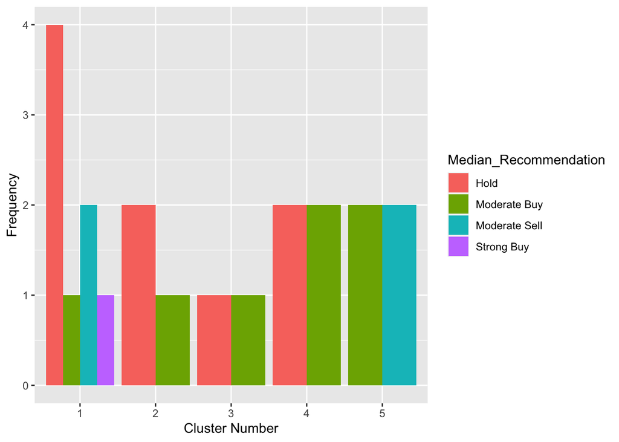

```r
# Utilizing bar charts
bar_chart_median_recommendation = ggplot(add_clusters_to_pharm_data, mapping = aes(factor(Cluster), fill=Median_Recommendation)) +
  geom_bar(position = 'dodge') + labs(x='Cluster Number', y='Frequency')
bar_chart_median_recommendation
```

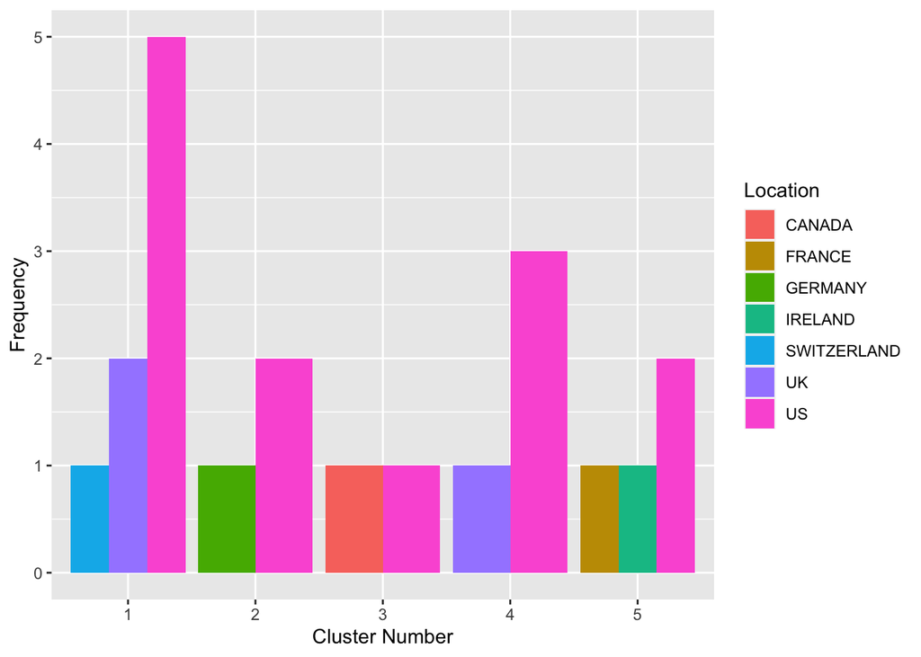

```r
bar_chart_location = ggplot(add_clusters_to_pharm_data, mapping = aes(factor(Cluster), fill=Location)) + geom_bar(position = 'dodge') + labs(x='Cluster Number', y='Frequency')
bar_chart_location
```

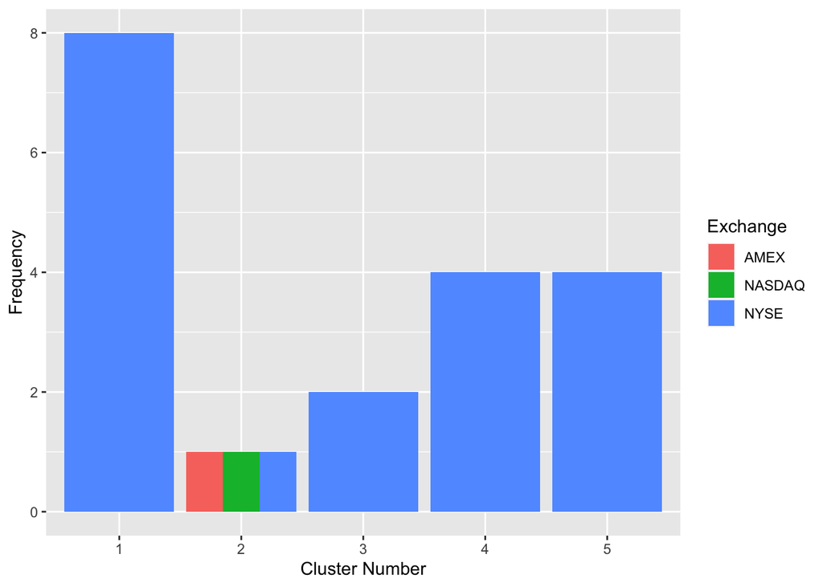

```r
bar_chart_exchange <- ggplot(add_clusters_to_pharm_data, mapping = aes(factor(Cluster), fill=Exchange)) +
geom_bar(position = 'dodge') + labs(x='Cluster Number', y='Frequency')
bar_chart_exchange
```

#### Companies from US and Canada are included in Cluster -3, and they are listed on the NYSE and have a moderate buy or hold recommendation, indicating that they may have some growth potential.

#### Companies from UK and the United States are included here and also received a hold or moderate buy recommendation in Cluster 4.

#### Companies from the US, Ireland and France make up Cluster -5. Their stocks on the NYSE have a moderate buy or moderate sell recommendation, indicating that they may have some growth potential but also equivalent risk.

# d. Provide an appropriate name for each cluster using any or all of the variables in the dataset.

Cluster 2: “Very Risky Firms with high debt”

Cluster 3: “Overpriced - Risky firms”

Cluster 4: “Established and very profitable firms”